# Challenge_5: Visualizing Time and Space

weekly_challenges

challenge_5

A Holloween Special

Author

Jeff Scheminger

Published

November 5, 2023

**Make sure you change the author’s name in the above YAML header.**

## Setup

If you have not installed the following packages, please install them before loading them.

```r
library(tidyverse)
library(readr)
library(readxl)
library(haven) #for loading other datafiles (SAS, STATA, SPSS, etc.)

#for plotting time
library(ggplot2) # if you have not installed this package, please install it.
library(lubridate)


#for plotting space
library(sp)
library(sf)
library(maps)
library(rnaturalearth)
library(rnaturalearthdata)
library(usmap)

knitr::opts_chunk$set(echo = TRUE, warning=FALSE, message=FALSE)
```

## Challenge Overview

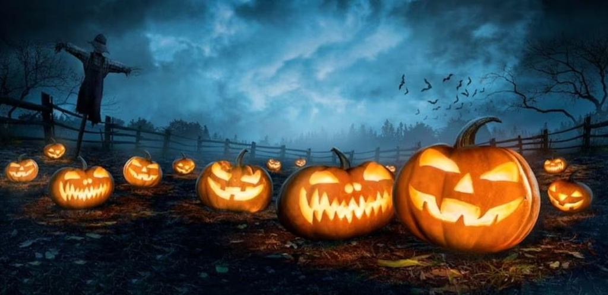

Halloween2023

In this challenge, we will practice the visualization skills learned in the class with two datasets to capture the temporal and spatial patterns of supernatural phenomena.

There will be coding components and writing components. Please read the instructions for each part and complete your challenges.

## Datasets

- Part 1. The UFO Sightings Data (50%)
- Part 2. The Haunted Places Data (50%)

Find the `_data` folder, then read the datasets using the correct R command.